# Apatite REE - Draft code

Santiago Ramos Galarza

May 06, 2026

# Load required libraries for data manipulation, visualization, and modeling

```r
library(tidyverse)
library(tidymodels)
library(broom)
library(infer)
library(rpart)
```

```r
library(rpart.plot)
```

# Loading data

```r
setwd("/cloud/project/project-starter")
df <- read_csv("data/apatite_data.csv")
```

# C1 Chondrite values (McDonough & Sun, 1995) [ppm]

```r
chondrite <- c(La=0.237, Ce=0.612, Pr=0.0912, Nd=0.457, Sm=0.148,
               Eu=0.0563, Gd=0.199, Tb=0.0361, Dy=0.246, Ho=0.0546,
               Er=0.160, Tm=0.0247, Yb=0.161, Lu=0.0246)
```

# Normalizing REEs and calculate the Eu anomaly

```r
df_clean <- df %>%
  mutate(
    La_N = La139_ppm_mean / chondrite["La"],
    Ce_N = Ce140_ppm_mean / chondrite["Ce"],
    Pr_N = Pr141_ppm_mean / chondrite["Pr"],
    Nd_N = Nd146_ppm_mean / chondrite["Nd"],
    Sm_N = Sm147_ppm_mean / chondrite["Sm"],
    Eu_N = Eu153_ppm_mean / chondrite["Eu"],
    Gd_N = Gd157_ppm_mean / chondrite["Gd"],
    Eu_anomaly = Eu_N / sqrt(Sm_N * Gd_N),
    Tb_N = Tb159_ppm_mean / chondrite["Tb"],
    Dy_N = Dy163_ppm_mean / chondrite["Dy"],
    Ho_N = Ho165_ppm_mean / chondrite["Ho"],
    Er_N = Er166_ppm_mean / chondrite["Er"],
    Tm_N = Tm169_ppm_mean / chondrite["Tm"],
    Yb_N = Yb172_ppm_mean / chondrite["Yb"],
    Lu_N = Lu175_ppm_mean / chondrite["Lu"],
  )
glimpse(df_clean)
```

```
## Rows: 177
## Columns: 67
## $ Sample         <dbl> 1, 2, 3, 4, 5, 6, 7, 8, 9, 10, 11, 12, 13, 14, 15, 16, …
## $ U238_ppm_mean  <dbl> 26, 25, 25, 31, 36, 35, 63, 31, 37, 32, 33, 33, 34, 30,…
## $ U238_ppm_2SE   <dbl> 1, 0, 1, 1, 1, 1, 1, 1, 1, 1, 1, 1, 1, 0, 1, 1, 1, 2, 1…
## $ Mg24_ppm_mean  <dbl> 128, 190, 238, 125, 75, 89, 80, 113, 148, 130, 110, 115…
## $ Mg24_ppm_2SE   <dbl> 2, 10, 28, 2, 2, 2, 2, 3, 10, 2, 4, 6, 2, 2, 3, 46, 18,…
## $ Al27_ppm_mean  <dbl> 3, 341, 414, 4, 3, 15, 12, 1, 19, 6, 2, 6, 2, 3, 5, 196…
## $ Al27_ppm_2SE   <dbl> 0, 102, 80, 0, 0, 5, 3, 0, 6, 1, 0, 1, 0, 0, 1, 37, 13,…
## $ Si28_ppm_mean  <dbl> 10586, 2100, 4144, 2174, 3053, 1529, 3547, 3118, 6542, …
## $ Si28_ppm_2SE   <dbl> 266, 199, 505, 182, 301, 388, 272, 321, 311, 412, 256, …
## $ P31_ppm_mean   <dbl> 95828, 98008, 92872, 92963, 99237, 93636, 93776, 93519,…
## $ P31_ppm_2SE    <dbl> 1106, 1135, 1280, 1619, 1441, 1513, 2119, 1154, 1130, 1…
## $ Ca43_ppm_mean  <dbl> 451059, 462119, 457676, 447646, 458163, 439088, 430582,…
## $ Ca43_ppm_2SE   <dbl> 5039, 5482, 5326, 7185, 5782, 7857, 9352, 7186, 4654, 5…
```

[output cut: 54 more lines]

```r
summary_table <- df_clean %>%
  group_by(Type) %>%
  summarize(
    Mean_Eu_Anomaly = mean(Eu_anomaly, na.rm = TRUE),
    SD_Eu_Anomaly = sd(Eu_anomaly, na.rm = TRUE),
    Count = n()
  )
summary_table
```

| Type | Mean_Eu_Anomaly | SD_Eu_Anomaly | Count |
| --- | --- | --- | --- |
| Barren | 0.2192606 | 0.05975813 | 69 |
| PCD | 0.5795699 | 0.30220167 | 108 |

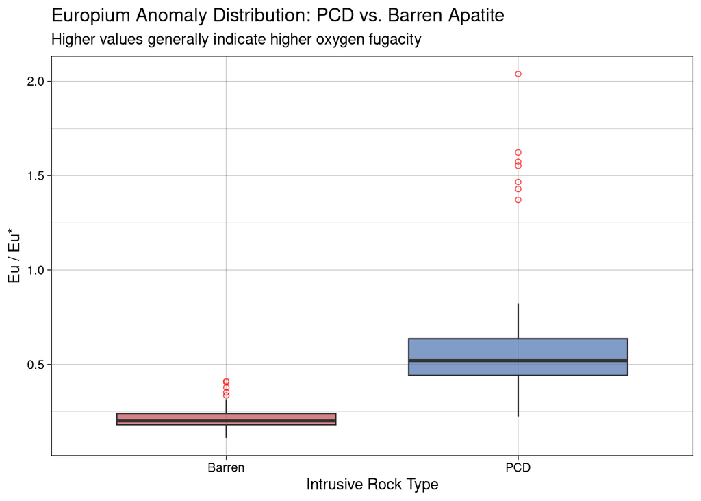

```r
ggplot(df_clean, aes(x = Type, y = Eu_anomaly, fill = Type)) +
  geom_boxplot(alpha = 0.7, outlier.color = "red", outlier.shape = 1) +
  theme_linedraw() +
  labs(
    title = "Europium Anomaly Distribution: PCD vs. Barren Apatite",
    subtitle = "Higher values generally indicate higher oxygen fugacity",
    x = "Intrusive Rock Type",
    y = expression("Eu / Eu*")
  ) +
  scale_fill_manual(values = c("PCD" = "#4C72B0", "Barren" = "#C44E52")) +
  theme(legend.position = "none")
```

## Randomization Test

**Null Hypothesis ($H_0$):** There is no difference in the mean $Eu/Eu^*$ between PCD and Barren apatite. The variables are independent. **Alternative Hypothesis ($H_A$):** There is a significant difference in the mean $Eu/Eu^*$ between the two groups.

```r
obs_diff <- df_clean %>%
  specify(Eu_anomaly ~ Type) %>%
  calculate(stat = "diff in means", order = c("PCD", "Barren"))

obs_diff
```

| stat |
| --- |
| 0.3603093 |

# Null distribution

```r
set.seed(12)

null_dist <- df_clean %>%
  specify(Eu_anomaly ~ Type) %>%
  hypothesize(null = "independence") %>%
  generate(reps = 1000, type = "permute") %>%
  calculate(stat = "diff in means", order = c("PCD", "Barren"))
```

# Visualize

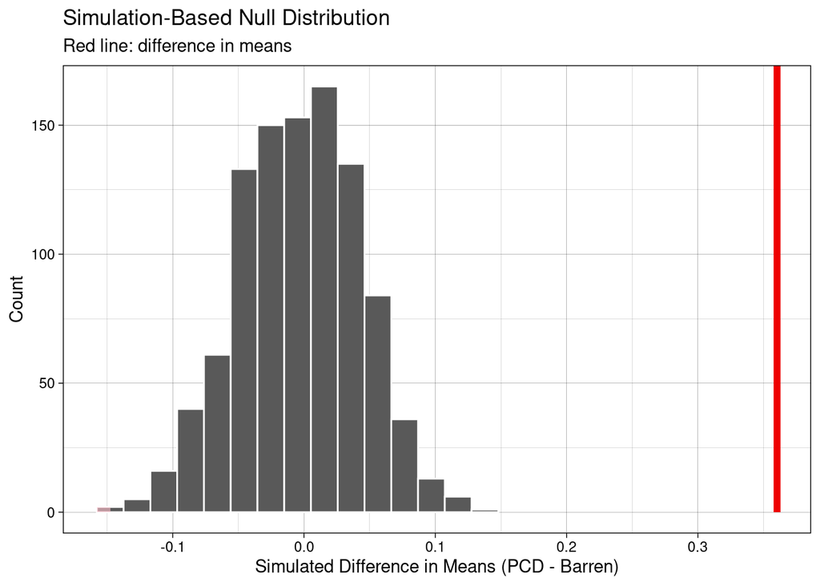

```r
visualize(null_dist) +
  shade_p_value(obs_stat = obs_diff, direction = "two-sided") +
  theme_linedraw() +
  labs(
    title = "Simulation-Based Null Distribution",
    subtitle = "Red line: difference in means",
    x = "Simulated Difference in Means (PCD - Barren)",
    y = "Count"
  )
```

```r
p_value <- null_dist %>%
  get_p_value(obs_stat = obs_diff, direction = "two-sided")
p_value
```

| p_value |
| --- |
| 0 |

## 5. Estimating the Difference: Bootstrap Confidence Intervals

While the randomization test tells us the difference is significant, we want to quantify the magnitude of this difference. I will calculate a 95% Bootstrap Confidence Interval for the difference in means $(\bar{x}_{PCD} - \bar{x}_{Barren})$.

```r
set.seed(12)

# Bootstrap distribution
boot_dist <- df_clean %>%
  specify(Eu_anomaly ~ Type) %>%
  generate(reps = 1000, type = "bootstrap") %>%
  calculate(stat = "diff in means", order = c("PCD", "Barren"))

# 95% CI
percentile_ci <- boot_dist %>%
  get_confidence_interval(level = 0.95, type = "percentile")

percentile_ci
```

| lower_ci | upper_ci |
| --- | --- |
| 0.3048002 | 0.4204128 |

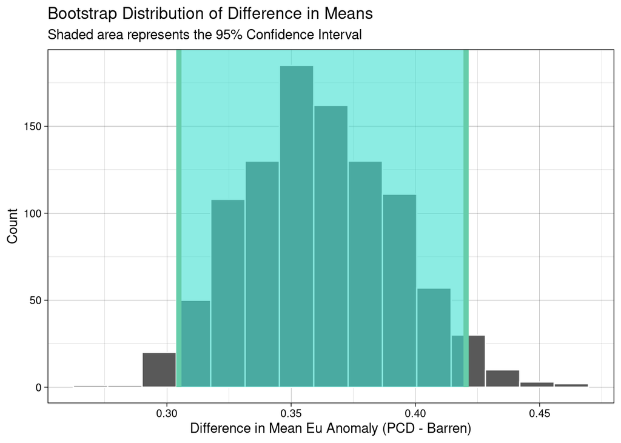

```r
# Visualize
visualize(boot_dist) +
  shade_confidence_interval(endpoints = percentile_ci) +
  theme_linedraw() +
  labs(
    title = "Bootstrap Distribution of Difference in Means",
    subtitle = "Shaded area represents the 95% Confidence Interval",
    x = "Difference in Mean Eu Anomaly (PCD - Barren)",
    y = "Count"
  )
```

## Simple Linear Model

slope as the difference between the PCD mean and the Barren mean

```r
eu_model <- lm(Eu_anomaly ~ Type, data = df_clean)
tidy(eu_model)
```

| term | estimate | std.error | statistic | p.value |
| --- | --- | --- | --- | --- |
| (Intercept) | 0.2192606 | 0.02879886 | 7.613517 | 1.594163e-12 |
| TypePCD | 0.3603093 | 0.03686804 | 9.772944 | 2.826235e-18 |

```r
glance(eu_model)
```

| r.squared | adj.r.squared | sigma | statistic | p.value | df | logLik | AIC | BIC | deviance | df.residual | nobs |
| --- | --- | --- | --- | --- | --- | --- | --- | --- | --- | --- | --- |
| 0.3530749 | 0.3493781 | 0.2392213 | 95.51044 | 2.826235e-18 | 1 | 3.028386 | -0.05677126 | 9.471678 | 10.0147 | 175 | 177 |

```r
model_results <- augment(eu_model)

rmse_calc <- model_results %>%
  summarize(RMSE = sqrt(mean(.resid^2)))

rmse_calc
```

| RMSE |
| --- |
| 0.2378659 |

## Predictive Modeling: Classification Tree (Tidymodels)

This will evaluate all normalized REEs simultaneously to find the optimal thresholds for distinguishing fertile (PCD) from barren magmas.

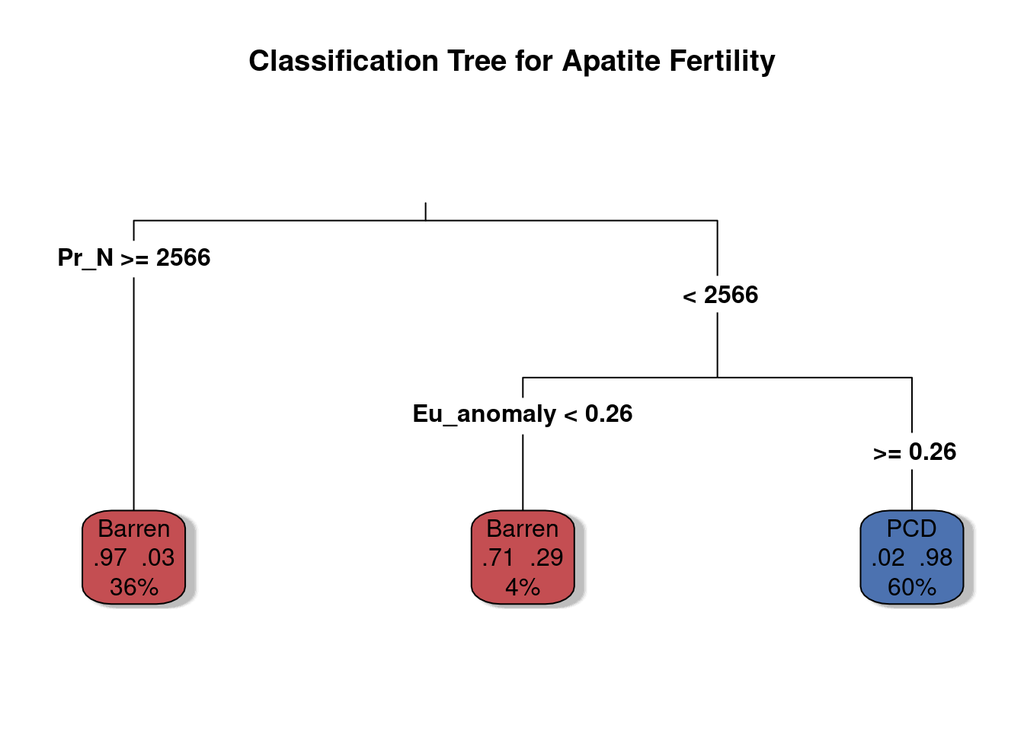

```r
tree_data <- df_clean %>%
  select(Type, Eu_anomaly, La_N:Lu_N)

tree_spec <- decision_tree() %>%
  set_mode("classification") %>%
  set_engine("rpart")

tree_recipe <- recipe(Type ~ ., data = tree_data)

tree_workflow <- workflow() %>%
  add_recipe(tree_recipe) %>%
  add_model(tree_spec)


tree_fit <- tree_workflow %>%
  fit(data = tree_data)

# Plot
tree_engine <- extract_fit_engine(tree_fit)

rpart.plot(tree_engine,
           main = "Classification Tree for Apatite Fertility",
           type = 3,
           extra = 104,
           box.palette = c("#C44E52", "#4C72B0"),
           shadow.col = "gray",
           fallen.leaves = TRUE)
```

### Geochemical Overlap: REE Spider Diagram

```r
spider_data <- df_clean %>%
  mutate(Sample_ID = row_number()) %>%
  select(Sample_ID, Type, ends_with("_N")) %>%
  pivot_longer(
    cols = ends_with("_N"),
    names_to = "Element",
    values_to = "Normalized_Value"
  ) %>%
  mutate(Element = str_remove(Element, "_N"))
```

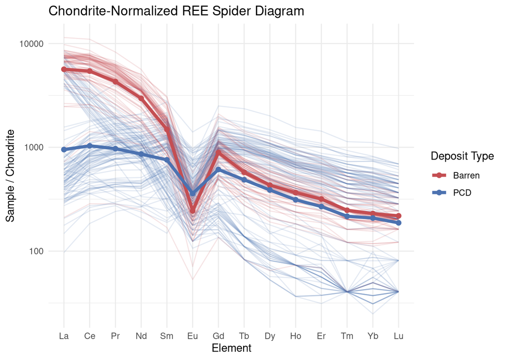

```r
ree_order <- c("La", "Ce", "Pr", "Nd", "Sm", "Eu", "Gd", "Tb", "Dy", "Ho", "Er", "Tm", "Yb", "Lu")
spider_data$Element <- factor(spider_data$Element, levels = ree_order)

ggplot(spider_data, aes(x = Element, y = Normalized_Value, color = Type)) +
  geom_line(aes(group = Sample_ID), alpha = 0.15) +
  stat_summary(aes(group = Type), fun = mean, geom = "line", linewidth = 1.5) +
  stat_summary(aes(group = Type), fun = mean, geom = "point", size = 2) +
  scale_y_log10() +
  theme_minimal() +
  labs(
    title = "Chondrite-Normalized REE Spider Diagram",
    y = "Sample / Chondrite",
    color = "Deposit Type"
  ) +
  scale_color_manual(values = c("PCD" = "#4C72B0", "Barren" = "#C44E52"))
```

## Comprehensive Analysis of All REEs

Instead of analyzing each Rare Earth Element individually, I will use functional programming (`purrr::map`) to iterate through all normalized REEs and the $Eu$ anomaly. This pipeline applies the simple linear model, the randomization test (1000 permutations), and the bootstrap confidence interval (1000 resamples) to every geochemical variable, compiling the results into a single summary table.

```r
# Group by the Element name
df_long <- df_clean %>%
  select(Type, Eu_anomaly, La_N:Lu_N) %>%
  pivot_longer(cols = -Type, names_to = "Element", values_to = "Value")

# Create a custom function that runs all tests on a single element
analyze_element <- function(sub_df) {
  set.seed(12)

  # Slope and R-Squared
  fit <- lm(Value ~ Type, data = sub_df)
  tidy_fit <- tidy(fit) %>% filter(term == "TypePCD")
  glance_fit <- glance(fit)

  # Observed Difference
  obs <- sub_df %>%
    specify(Value ~ Type) %>%
    calculate(stat = "diff in means", order = c("PCD", "Barren"))

  # Randomization Test
  null_dist <- sub_df %>%
    specify(Value ~ Type) %>%
    hypothesize(null = "independence") %>%
    generate(reps = 1000, type = "permute") %>%
    calculate(stat = "diff in means", order = c("PCD", "Barren"))

  p_val <- null_dist %>% get_p_value(obs_stat = obs, direction = "two-sided")

  # Bootstrap CI
  boot_dist <- sub_df %>%
    specify(Value ~ Type) %>%
    generate(reps = 1000, type = "bootstrap") %>%
    calculate(stat = "diff in means", order = c("PCD", "Barren"))

  ci <- boot_dist %>% get_confidence_interval(level = 0.95, type = "percentile")

  # Summarize
  tibble(
    Difference_in_Means = tidy_fit$estimate,
    R_Squared = glance_fit$r.squared,
    Rand_P_Value = p_val$p_value,
    CI_Lower = ci$lower_ci,
    CI_Upper = ci$upper_ci
  )
}

# Summary table
all_results <- df_long %>%
  nest(.by = Element) %>% # Group data by Element into 'lists'
  mutate(results = map(data, analyze_element)) %>% # Run the custom function
  unnest(results) %>%
  select(-data) %>%
  arrange(Rand_P_Value, desc(R_Squared))
knitr::kable(all_results, digits = 4,
             caption = "Statistical Summary for All Geochemical Proxies (PCD vs. Barren)")
```

Statistical Summary for All Geochemical Proxies (PCD vs. Barren)

| Element | Difference_in_Means | R_Squared | Rand_P_Value | CI_Lower | CI_Upper |
| --- | --- | --- | --- | --- | --- |
| Pr_N | -3541.6887 | 0.7262 | 0.000 | -3916.3028 | -3169.2894 |
| Ce_N | -4559.7668 | 0.6995 | 0.000 | -5061.2723 | -4062.2417 |
| Nd_N | -2215.2542 | 0.6737 | 0.000 | -2474.3732 | -1961.9822 |
| La_N | -4329.5980 | 0.4722 | 0.000 | -4983.2641 | -3659.7099 |
| Eu_anomaly | 0.3603 | 0.3531 | 0.000 | 0.3058 | 0.4263 |
| Sm_N | -678.2407 | 0.2645 | 0.000 | -850.4130 | -517.7063 |
| Eu_N | 163.2830 | 0.1401 | 0.000 | 110.4300 | 212.5500 |
| Yb_N | 81.3255 | 0.0394 | 0.008 | 30.2237 | 129.5561 |
| Tm_N | 84.4922 | 0.0359 | 0.008 | 28.9336 | 136.9186 |
| Gd_N | -169.3997 | 0.0346 | 0.014 | -291.2068 | -54.7879 |
| Dy_N | 127.1274 | 0.0307 | 0.016 | 34.6093 | 211.6602 |
| Er_N | 79.2849 | 0.0230 | 0.040 | 11.5484 | 140.5461 |
| Ho_N | 87.8295 | 0.0223 | 0.046 | 12.4988 | 158.1271 |
| Lu_N | 52.4331 | 0.0222 | 0.048 | 9.4891 | 94.8039 |
| Tb_N | 81.6082 | 0.0097 | 0.212 | -24.6498 | 182.5559 |